# Split-plot

## Today’s goals

Explore key concepts in split-plot:

1. Different sizes of EU
2. Treatment randomization
3. The effects model
4. The ANOVA table

## Motivational example - Treatment design

- 2-way factorial
- N fertilizer rates: 0, 100, 200 kg N/ha
- K fertilizer rates: 0, 30, 60 kg K/ha
- 3 x 3 = **9 treatment combinations**

## When is split-plot needed?

1. When levels of one treatment factor need more/less experimental material than the levels of other treatment factors

For ex., K treatments are applied with a 12-row spreader, and N rates are applied with a 4-row coulter.

[figure not shown]

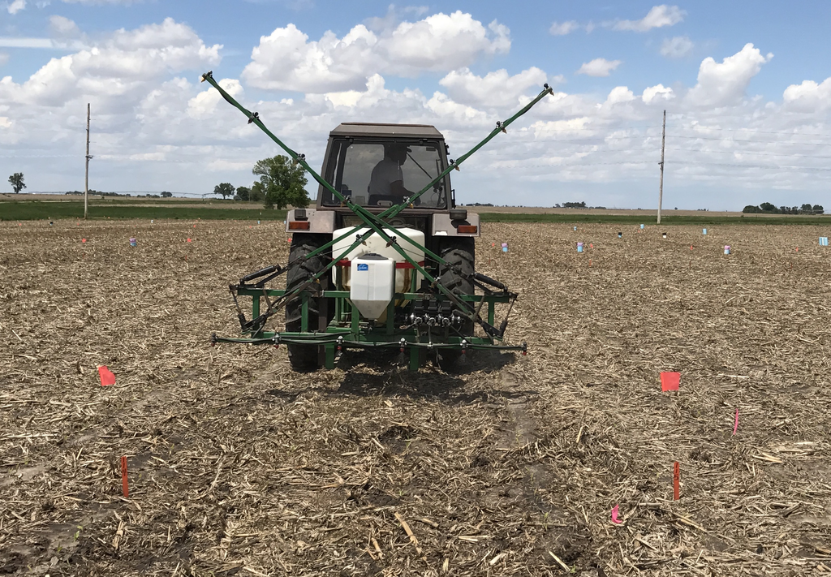

## When is split-plot needed?

2. Don’t have enough experimental material to have all plots be the size of the requirements of treatment factor needing more resources
- In the example above, we could, potentially, decide to have all plots of size 12 rows, where a given **K treatment** is applied with **one pass on the plot**, and a given **N treatment** is applied with **3 passes on the plot**.
- In that, we would need **36 plots x 12 rows/plot = 432 rows total**

## When is split-plot needed?

2. Don’t have enough experimental material to have all plots be the size of the requirements of treatment factor needing more resources
- However, that requires more land than we anticipated (we planed for 4-row plots), and we only have space for **36 plots x 4 rows = 144 rows total**

## When is split-plot needed?

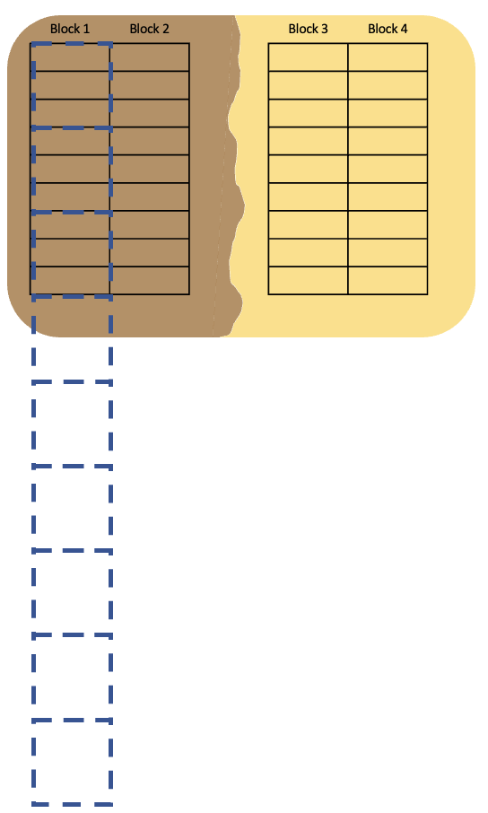

## Motivational example - Treatment design in a split-plot

- 2-way factorial **in a split-plot**
- **Whole-plot** treatment factor: K fertilizer rates: 0, 30, 60 kg K/ha
- **Split-plot** treatment factor: N fertilizer rates: 0, 100, 200 kg N/ha
- 3 x 3 = **9 treatment combinations** that will be assigned to different sizes of experimental units!

## Experimental design

A split-plot can be used with different experimental designs like **CRD or RCBD**

Assuming we have **heterogeneous** experimental material (e.g., different soil type, topography, etc.)

- Thus, we should use a **randomized complete block design (RCBD)**

## Treatment randomization - Split-plot in RCBD

1. We first randomize the levels of the **whole-plot** treatment factor within each of our blocks.

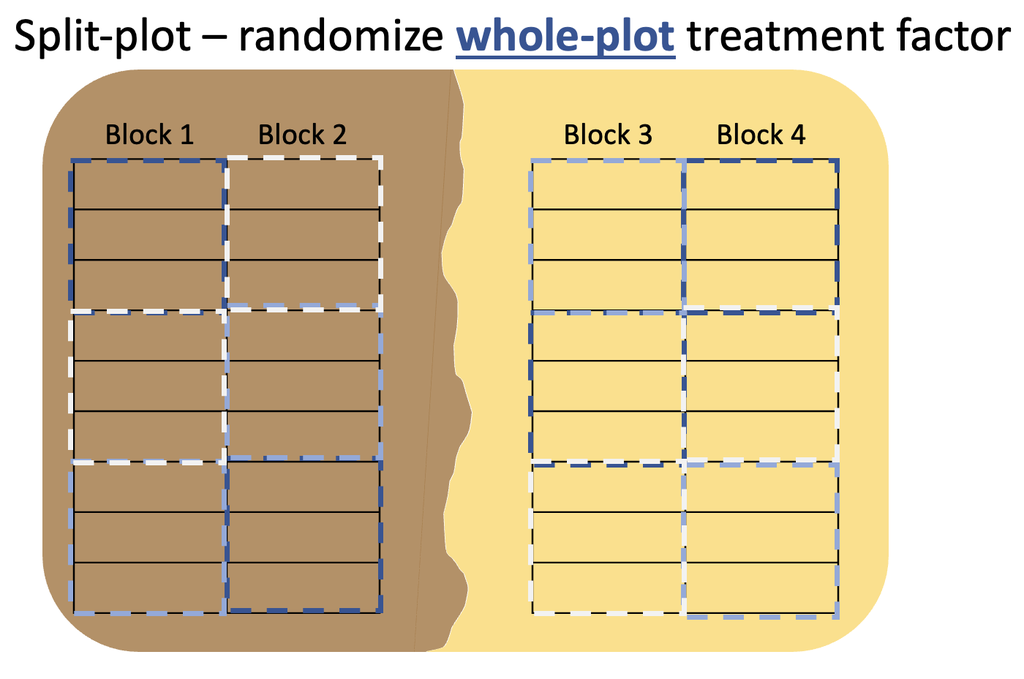

## Treatment randomization - Split-plot in RCBD

2. Then we randomize the levels of the **split-plot** treatment factor within each of our whole-plot treatment factor plots.

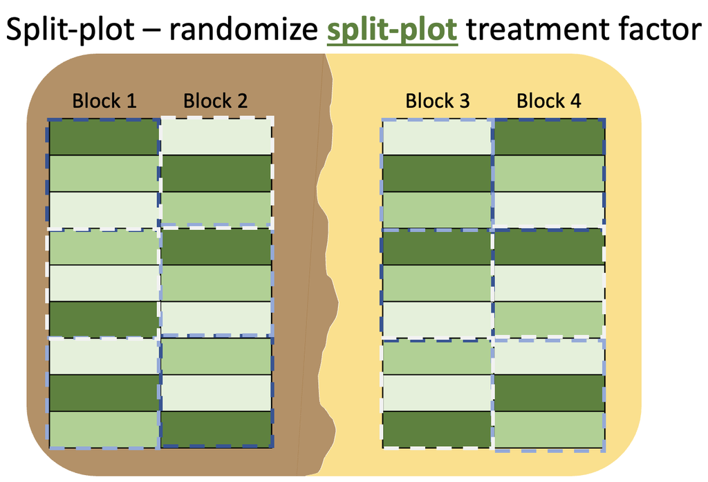

## The effects model

$$y_{ijk} = \mu + \rho_{k} + \alpha_{i} + (\alpha\rho)_{ik} + \beta_{j} + (\alpha\beta)_{ij} + e_{ijk}$$

- $y_{ijk}$ is the observation on the kth block from ith K rate and jth N rate
- $\mu$ is the overall mean
- $\rho_{k}$ is the random effect of kth block
- $\alpha_{i}$ is the differential effect of ith K rate
- $(\alpha\rho)_{ik}$ is the whole-plot random error
- $\beta_{j}$ is the differential effect of jth N rate
- $(\alpha\beta)_{ij}$ is the differential effect of the combination of the ith N rate and ith K rate
- $e_{ijk}$ is the residual corresponding to the block k of K rate i and N rate j.

## The ANOVA table

In the following ANOVA table…

- *n* is number of levels in N rate = 3
- *k* is number of levels in K rate = 3
- *r* is number of blocks = 4
- *N* is total number of obserevations or EUs = 3 x 3 x 4 = 36

## The ANOVA table

| Source of variation | df | SS | MS | F ratio |
| --- | --- | --- | --- | --- |
| Block | dfb = r - 1 = 4 - 1 = 3 | SSb |  |  |
| K rate | dfk = k - 1 = 3 - 1 = 2 | SSk | MSk = SSk / dfk | MSk / MSwpe |
| WP error (K x Block) | dfwpe = (k - 1) x (r - 1) = (3 - 1) x (4 - 1) = 6 | SSwpe | MSwpe = SSwpe / dfwpe |  |
| N rate | dfn = n - 1 = 3 - 1 = 2 | SSn | MSn = SSn / dfn | MSn / MSspe |
| N x K | dfnk = (n - 1) x (k - 1) = (3-1) x (3-1) = 4 | SSnk | MSnk = SSnk / dfnk | MSnk / MSspe |
| SP error | dfspe = k(r - 1) x (n - 1) = 3(4 - 1) x (3 - 1) = 9 x 2 = 18 | SSspe | MSspe = SSspe / dfspe |  |
| TOTAL | dft = N -1 = 35 | SSt |  |  |

- Notice how we have 2 error sources: the WP and the SP.
- What would happen if we ran this mistakenly as full RCBD with a single EU size?

## ANOVA table - motivational example

| Source of variation | Chisq | Df | Pr(>Chisq) |
| --- | --- | --- | --- |
| (Intercept) | 913.7660083 | 1 | <0.001 |
| krate_kgha | 0.9183707 | 2 | 0.632 |
| nrate_kgha | 4.5029460 | 2 | 0.105 |
| krate_kgha:nrate_kgha | 33.5440880 | 4 | <0.001 |

- What is significant here (say at $\alpha = 0.05$)?
- ANOVA table only provides numerator df! Denominator df is important to know as well to check that proper errors are being used to test different effects.

## The split-plot trade-off

Compared to a RCBD where each of the 3 N x 3 K combinations would have been randomly assigned to same-sized EUs:

- The **whole-plot** treatment factor has **power decreased**
- The **split-plot** treatment factor has **power increased**
- Overall, split-plot designs have relatively lower power than their same-sized EU counterpart

## Summary

- Split-plot designs are used when different treatment factors require a different size/amount of experimental material
- Split-plots have one treatment factor allocated to the whole-plot experimental units (larger), and another treatment factor allocated to the split-plot experimental units (smaller)

## Summary

- Due to randomization happening at two different levels, that creates 2 different experimental errors, one for each experimental unit size. Need to ensure that proper model is specified so proper errors are used.
- Although split-plot treatment factor has increased power, overall split-plot designs have less power compared to their one-EU-size counterpart.